# Medicare data challenge

Ying Li

2017.11.27

# 1. Why home health care?

The reason I learn statistics is that I am obsessed with health-related statistics. After I came to the US when I was checking my health insurance, I find that there are lots of home health care agencies that can bring health care services to your home. This is very unusual compared to China and I am always interested in things that are new to me. So I decided to focus on home health care agncies.

When people are choosing their own home health care agency, there are many things that take into consideration, like:

1. What kind of health care service are they offering?
2. Are the health provider nice?
3. What are the prices?
4. Are the doctors experienced?

What’s more? A lot of people write reviews for certain agncy, What factors could influence them when writing a reviews? Why would they give an agency five stars?

For this project, I will be finding out the factors that could influence the star rate of each agency start. And does the state location influence the star rating for each agency.

# 2. Subsetting the Large Datasets

I use the website “https://data.medicare.gov/Home-Health-Compare/Home-Health-Care-Agencies/6jpm-sxkc” to get the data. This datasets consists of lots of variables including the address of each agency and some footnote for the variables. So I delete those variables that I think is not relevant to my project. From the data I subsetted the data by keeping data with state category and some other variables that I think that could influence that star rating of an agency.

After subsetting the datasets, my final datasets have 11742 agencies and their ratings.

The column names of this datasets are all long senteces therefore I make some abbreviation to simplfy the column names.

```r
library(ggplot2)
library(dplyr)
hca1<-read.csv("Home_Health_Care_Agencies.csv")
colnames(hca1)[1]<-c("State")
hca2<-hca1[-c(2,3,4,6,7,8,15,17,19,21,23,25,27,29,31,33,35,37,39,41,43,45,47,49,50,51,52,53,54)]
colnames(hca2)<-c("state","city","NC","PT","OT","SP","MS","HHA","rating","begin_care","teach_drug","falling","depression","flu_shot","pneu_vac","foot_care","walking","bed","bathing","pain","breath","operation","take_drug","hospital","ER")
hca2$NC<-ifelse(hca2$NC=="true",1,0)
hca2$PT<-ifelse(hca2$PT=="true",1,0)
hca2$OT<-ifelse(hca2$OT=="true",1,0)
hca2$SP<-ifelse(hca2$SP=="true",1,0)
hca2$MS<-ifelse(hca2$MS=="true",1,0)
hca2$HHA<-ifelse(hca2$HHA=="true",1,0)
hca<-hca2[-3]
hca<-na.omit(hca)
```

# 3. EDA

## 3.1 counts of the star ratings

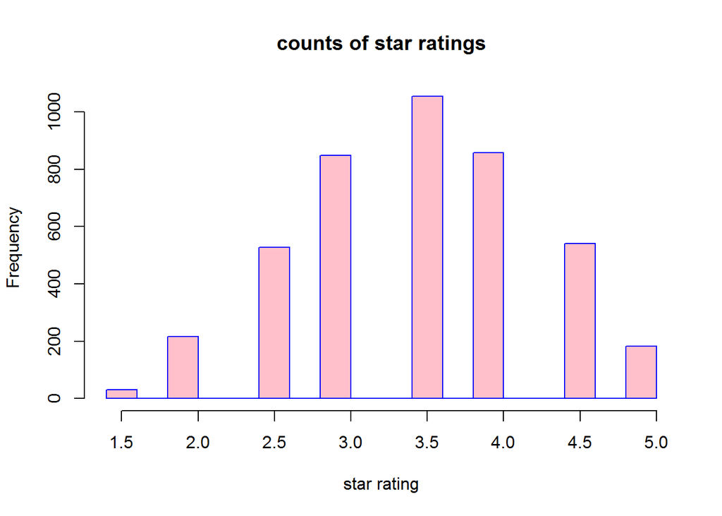

```r
hist(hca$rating,main = "counts of star ratings",xlab="star rating",col="pink",border = "blue")
```